# Statistical analysis of water discharge of surface streams

Large amounts of historical surface water data are available from the United States Geological Survey (USGS) at https://waterdata.usgs.gov/nwis The goal of the project is to retrieve samples from the web interface manually, and then later automate the process by calling the web service as described at https://help.waterdata.usgs.gov/faq/automated-retrievals.

## Excercise 1

For the purposes of the current excercises, select a stream from a rainy area with relatively small discharge so that the effect of short but strong storms is visible. Good choices are small rivers from the north-eastern US, e.g. site 01589440. Retrieve at least 10 years of data.

## Excercise 2

Load the downloaded data file into the processing environment paying attention to handling time stamps and perfoming the necessary data type conversions. Converting dates to floating point numbers such as unix time stamp or julian date usually makes handling time series easier. Plot the data for a certain interval to show that the effect of storms is clearly visible.

|  | agency_cd | site_no | datetime | tz_cd | Discharge | 69679_00060_cd | Gage | 69680_00065_cd |
| --- | --- | --- | --- | --- | --- | --- | --- | --- |
| 0 | USGS | 1585500 | 2008-01-01 00:00:00 | EST | 1.90 | A | 1.49 | A |
| 1 | USGS | 1585500 | 2008-01-01 00:15:00 | EST | 1.90 | A | 1.49 | A |
| 2 | USGS | 1585500 | 2008-01-01 00:30:00 | EST | 1.90 | A | 1.49 | A |
| 3 | USGS | 1585500 | 2008-01-01 00:45:00 | EST | 1.78 | A | 1.48 | A |
| 4 | USGS | 1585500 | 2008-01-01 01:00:00 | EST | 1.78 | A | 1.48 | A |

```
<function matplotlib.pyplot.tight_layout(*, pad=1.08, h_pad=None, w_pad=None, rect=None)>
```

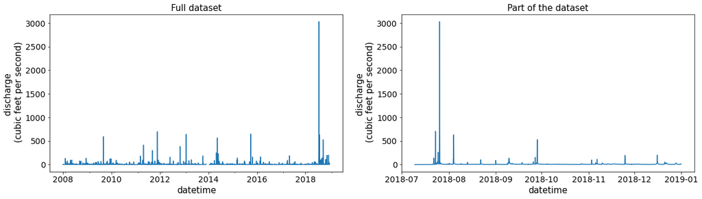

## Excercise 3

Plot the histogram of water discharge values. Fit the data with an appropriate distribution function and bring arguments in favor of the choice of function.

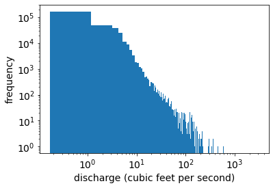

```
Fitted function:  3126070.9712534575 x^(-3.0597083532939275)
```

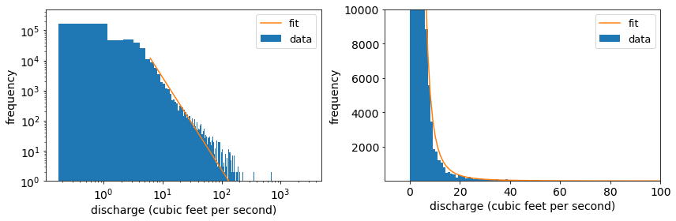

Intuitively, higher values of discharge are less likely. The diagrams match with this.  
In the nature, we can find several events following power law.

## Excercise 4

In case of small streams, storms and passing weather fronts with rain can significantly increase water discharge on a short time scale. Develop a simple algorithm to detect rainy events in the data. Plot the original time series and mark rainy events.

There is a function in scipy.signal package which finds the peaks in an array of elements. I added two restrictions to the algorithm to have only the significant peaks instead of all. Based on the first diagram of the discharge the minimum value was set to 10 and the minimum distance between two peaks to 8. The explaination for the latter is that two rainy events are different if at least 2 hours (8 measurements) passed.

```
379  rainy events detected.
```

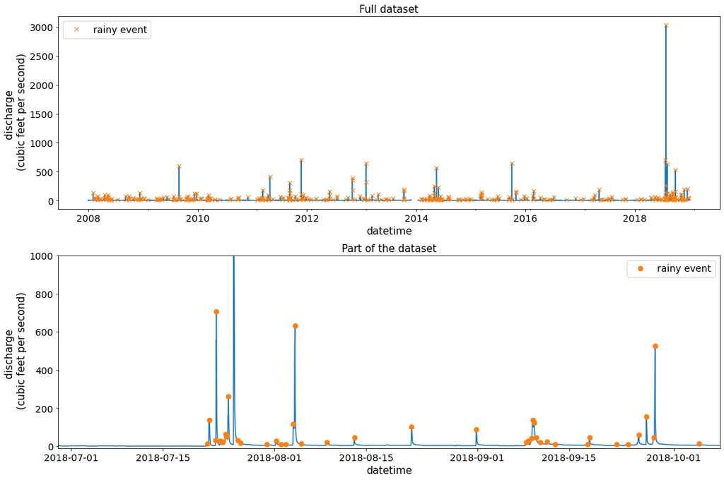

## Excercise 5

Water discharge increases significantly during rain producing maxima in the time series. Plot the distribution of maximum values and fit with an appropriate function. Bring arguments to support the choice of probabilistic model.

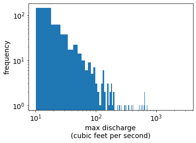

```
Fitted function:  70695.2773871284 x^(-2.1441350528396077)
```

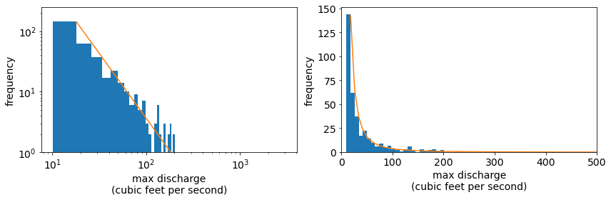

It is also a power-law distribution.

## Excercise 6

Once rainy events are detected, plot the distribution of the length of sunny intervals between rains. Fit the distribution with an appropriate function.

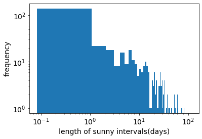

```
Fitted function:  66.73022781236877 x^(-1.0020238980326828)
```

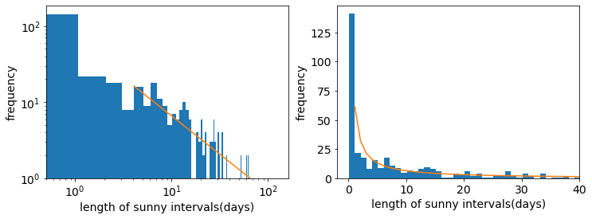

We can see again the power-law distribution.

## Excercise 7

[output not shown]

[output not shown]

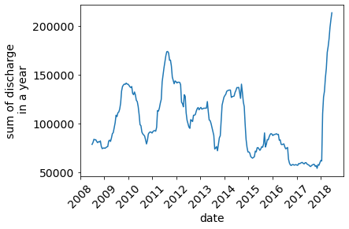

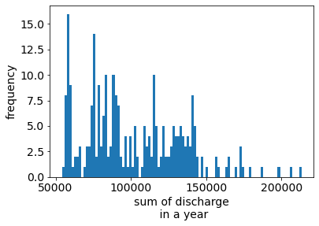

## Excercise 8

How many time does it rain in a month? Calculate and plot the distribution and fit with an appropriate function.

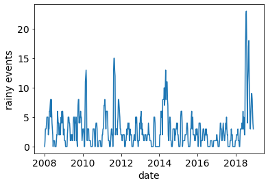

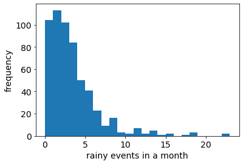

```
Fitted Gaussian function coefficients:
 a= 110.247
 x_0= 1.723
 sigma= 2.08
```

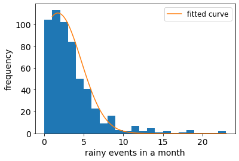

## Excercise 9

Find the measuring station you used in the excercises above on the map. Find another measurement station about 100-200 miles from it and download the data. Try to estimate the typical time it takes for weather fronts to travel the distance between the two measuring stations.

The chosen other river is USGS 01562000 Raystown Branch Juniata River at Saxton, PA

|  | agency_cd | site_no | datetime | tz_cd | Discharge | 122013_00060_cd | 122014_00065 | 122014_00065_cd |
| --- | --- | --- | --- | --- | --- | --- | --- | --- |
| 0 | USGS | 1562000 | 2008-01-01 00:00:00 | EST | 1130.0 | A | 2.92 | A |
| 1 | USGS | 1562000 | 2008-01-01 00:15:00 | EST | 1130.0 | A | 2.92 | A |
| 2 | USGS | 1562000 | 2008-01-01 00:30:00 | EST | 1130.0 | A | 2.92 | A |
| 3 | USGS | 1562000 | 2008-01-01 00:45:00 | EST | 1130.0 | A | 2.92 | A |
| 4 | USGS | 1562000 | 2008-01-01 01:00:00 | EST | 1130.0 | A | 2.92 | A |

My algorithm is the following. First, I searched for the highest five peaks in the first dataset. Then, I searched for the maximum values in the second dataset, in a $\pm$ 1 day interval around the previous top 5 measurements.

```
Largest 5 values of the discharge: [698.0, 642.0, 3030.0, 646.0, 706.0]
```

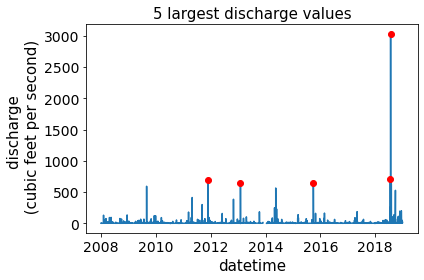

```
Shifts between the same event at different place:
15  hours 16  minutes
```

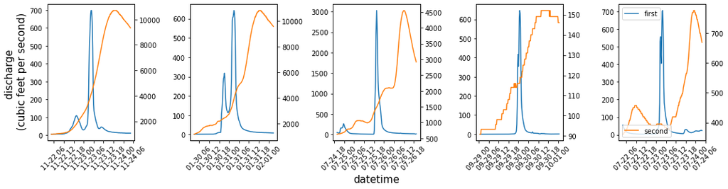